# Homework 6

Alex Rintamaa

2024-05-06

```r
# Load the library
library(pdfCluster)
library(caret)
# Open help menu
?oliveoil
# Load data for accessing
data("oliveoil")
```

1. Using 10-fold cross validation, fit and tune a support vector classifier for predicting the region of each oil sample. Report any tuning parameters chosen, as well as the overall misclassification rate.

```r
# SVM Linear
olive.svc <- train(region ~ .,
             data =oliveoil,
             method = "svmLinear",
             trControl = trainControl("repeatedcv", number = 10, repeats = 10),
             tuneGrid = expand.grid(C = c(0.1, 1, 10, 100)))

olive.svc$bestTune
```

```
##   C
## 2 1
```

```r
olive.svc$results
```

```
##       C  Accuracy     Kappa AccuracySD    KappaSD
## 1   0.1 0.9486933 0.9368879 0.02726974 0.03348804
## 2   1.0 0.9586133 0.9491966 0.02463303 0.03020733
## 3  10.0 0.9556050 0.9454450 0.02836388 0.03484406
## 4 100.0 0.9486097 0.9370155 0.02529684 0.03101632
```

```r
olive.misclass_svc<- 1 - max(olive.svc$results$Accuracy)
olive.misclass_svc
```

```
## [1] 0.04138672
```

2. Using 10-fold cross validation, fit and tune a support vector machine with a polynomial kernel for predicting the region of each oil sample. Report any tuning parameters chosen, as well as the overall misclassification rate.

```r
# SVM Polynomial
olive.svmP <- train(region ~ .,
             data=oliveoil,
             method="svmPoly",
             trControl=trainControl("repeatedcv", number=10, repeats=10),
             tuneGrid=expand.grid(C=c(1,10,100),
                                 degree=2:4,
                                 scale=1))
olive.svmP$bestTune
```

```
##   degree scale C
## 1      2     1 1
```

```r
olive.svmP$results
```

```
##     C degree scale  Accuracy     Kappa AccuracySD    KappaSD
## 1   1      2     1 0.9441794 0.9315485 0.02757345 0.03373569
## 4  10      2     1 0.9424251 0.9295063 0.02943519 0.03592141
## 7 100      2     1 0.9424251 0.9295063 0.02943519 0.03592141
## 2   1      3     1 0.9428010 0.9298605 0.03048786 0.03733934
## 5  10      3     1 0.9428010 0.9298605 0.03048786 0.03733934
## 8 100      3     1 0.9428010 0.9298605 0.03048786 0.03733934
## 3   1      4     1 0.9430352 0.9301303 0.02940507 0.03595839
## 6  10      4     1 0.9430352 0.9301303 0.02940507 0.03595839
## 9 100      4     1 0.9430352 0.9301303 0.02940507 0.03595839
```

```r
olive.misclass_svmP<- 1 - max(olive.svmP$results$Accuracy)
olive.misclass_svmP
```

```
## [1] 0.05582058
```

3. Using 10-fold cross validation, fit and tune a support vector machine with a radial kernel for predicting the region of each oil sample. Report any tuning parameters chosen, as well as the overall misclassification rate.

```r
# SVM Radial
olive.svmR <- train(region ~ .,
              data = oliveoil,
              method = "svmRadial",
              trControl = trainControl("repeatedcv", number = 10, repeats = 10),
              tuneGrid = expand.grid(C = c(0.1, 1, 10, 100),
                                     sigma = c(0.01, 0.1, 1, 10)))
olive.svmR$bestTune
```

```
##    sigma   C
## 13  0.01 100
```

```r
olive.misclass_svmR<- 1 - max(olive.svmR$results$Accuracy)
olive.misclass_svmR
```

```
## [1] 0.03928606
```

4. Which model from 1-3 is best at classifying the regions? Display the confusion matrix for the best model. Are there some regions where the classifier performs particularly well (with very few related misclassifications)?

```r
# Compare SVM models using resampling
summary(resamples(list(linear = olive.svc,
                       poly = olive.svmP,
                       rad = olive.svmR)))
```

```
##
## Call:
## summary.resamples(object = resamples(list(linear = olive.svc, poly
##  = olive.svmP, rad = olive.svmR)))
##
## Models: linear, poly, rad
## Number of resamples: 100
##
## Accuracy
##             Min.   1st Qu.    Median      Mean   3rd Qu. Max. NA's
## linear 0.8620690 0.9473684 0.9642857 0.9586133 0.9818182    1    0
## poly   0.8620690 0.9298246 0.9473684 0.9441794 0.9644424    1    0
## rad    0.9122807 0.9473684 0.9642857 0.9607139 0.9821429    1    0
##
## Kappa
##             Min.   1st Qu.    Median      Mean   3rd Qu. Max. NA's
## linear 0.8326722 0.9351733 0.9563119 0.9491966 0.9776467    1    0
## poly   0.8307805 0.9140189 0.9357311 0.9315485 0.9564035    1    0
## rad    0.8903002 0.9359269 0.9562756 0.9517756 0.9778873    1    0
```

```r
predictions_svmr <- predict(olive.svmR, newdata = oliveoil)

# Create the confusion matrix
confusion_matrix_svmr <- confusionMatrix(predictions_svmr, oliveoil$region)
confusion_matrix_svmr
```

```
## Confusion Matrix and Statistics
##
##                  Reference
## Prediction        Apulia.north Calabria Apulia.south Sicily Sardinia.inland
##   Apulia.north              25        0            0      2               0
##   Calabria                   0       55            0      2               0
##   Apulia.south               0        1          203      3               0
##   Sicily                     0        0            3     29               0
##   Sardinia.inland            0        0            0      0              65
##   Sardinia.coast             0        0            0      0               0
##   Liguria.east               0        0            0      0               0
##   Liguria.west               0        0            0      0               0
##   Umbria                     0        0            0      0               0
##                  Reference
## Prediction        Sardinia.coast Liguria.east Liguria.west Umbria
##   Apulia.north                 0            0            0      0
##   Calabria                     0            0            0      0
##   Apulia.south                 0            0            0      0
##   Sicily                       0            0            0      0
##   Sardinia.inland              0            0            0      0
##   Sardinia.coast              33            0            0      0
##   Liguria.east                 0           50            0      0
##   Liguria.west                 0            0           50      0
##   Umbria                       0            0            0     51
##
## Overall Statistics
##
##                Accuracy : 0.9808
##                  95% CI : (0.9659, 0.9904)
##     No Information Rate : 0.3601
##     P-Value [Acc > NIR] : < 2.2e-16
##
##                   Kappa : 0.9764
##
##  Mcnemar's Test P-Value : NA
##
## Statistics by Class:
##
##                      Class: Apulia.north Class: Calabria Class: Apulia.south
## Sensitivity                      1.00000         0.98214              0.9854
```

[output cut: 10 more lines]

```
## Pos Pred Value             0.90625                 1.0000               1.00000
## Neg Pred Value             0.98704                 1.0000               1.00000
## Prevalence                 0.06294                 0.1136               0.05769
## Detection Rate             0.05070                 0.1136               0.05769
## Detection Prevalence       0.05594                 0.1136               0.05769
## Balanced Accuracy          0.89998                 1.0000               1.00000
##                      Class: Liguria.east Class: Liguria.west Class: Umbria
## Sensitivity                      1.00000             1.00000       1.00000
## Specificity                      1.00000             1.00000       1.00000
## Pos Pred Value                   1.00000             1.00000       1.00000
## Neg Pred Value                   1.00000             1.00000       1.00000
## Prevalence                       0.08741             0.08741       0.08916
## Detection Rate                   0.08741             0.08741       0.08916
## Detection Prevalence             0.08741             0.08741       0.08916
## Balanced Accuracy                1.00000             1.00000       1.00000
```

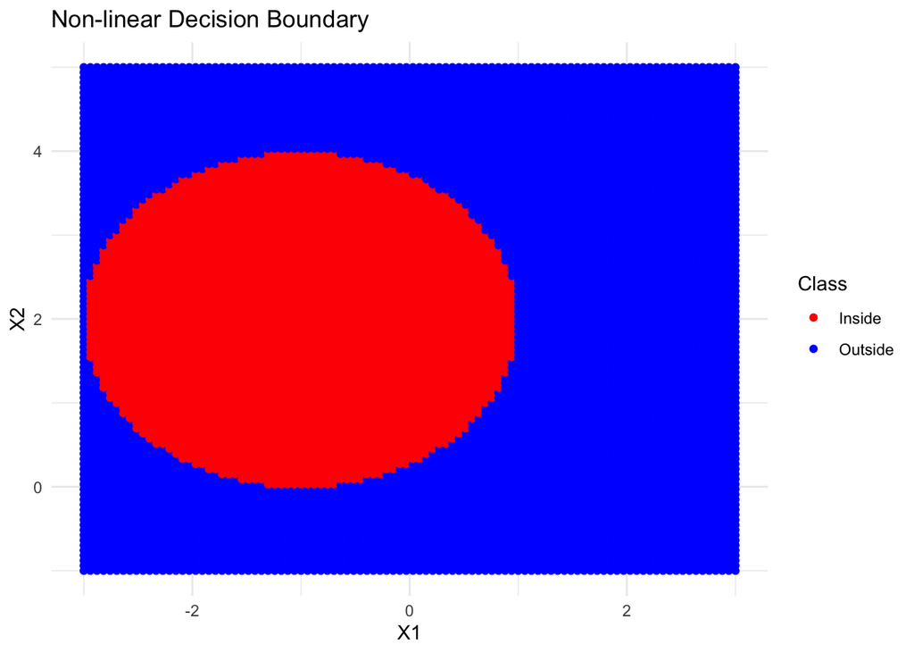

```r
library(ggplot2)
# Define the curve equation
curve_eq <- function(X1, X2) {
  return((1 + X1)^2 + (2 - X2)^2 - 4)
}

# Generate data points for plotting
X1 <- seq(-3, 3, length.out = 100)
X2 <- seq(-1, 5, length.out = 100)
data <- expand.grid(X1 = X1, X2 = X2)
data$Class <- ifelse(curve_eq(data$X1, data$X2) > 0, "Outside", "Inside")



# Plot
ggplot(data, aes(x = X1, y = X2, color = Class, fill = Class)) +
  geom_point(size = 1.5) +
  geom_contour(aes(z = curve_eq(X1, X2)), breaks = 0, color = "black") +
  theme_minimal() +
  scale_color_manual(values = c("red", "blue"), name = "Class") +
  scale_fill_manual(values = c("red", "blue"), name = "Class") +
  labs(title = "Non-linear Decision Boundary") +
  theme(legend.position = "right")
```

3. (0,0) has blue class classification (-1,1) has red class classification (2,2) has blue class classification (3,8) has blue class classification
4. By completing the square, you can get

$$X_{1}^{2} + X_{2}^{2} + 2X_{1} - 4X_{2}
+ 1 = 0$$

To solve for any term in terms of a linear formula, it is quite easy.